# Lab 9: Simulation Exploration

Author

Trycia Vong

```r
library(tidyverse)
library(broom)
library(knitr)
library(purrr)
```

## Random Babies Simulation

Perhaps you have seen the [Random Babies applet](https://www.rossmanchance.com/applets/2021/randombabies/RandomBabies.html)? Suppose one night at a hospital some number of babies are born. The hospital is not very organized and looses track of which baby belongs to each parent(s), so they decide to return the babies to parents *at random*. Here, we are interested in the number of babies that are correctly returned to their respective parent(s).

**1. Simulate the distribution of the number of babies that are correctly returned if there were four babies born in a night at our disorganized hospital. Use 10,000 simulations. Make sure to add a line of code to make your simulation reproducible every time you run it.**

**Tip**

First, write a function to accomplish one simulation (i.e. one night), given a number of babies (`n_babies`) that were born in a hospital on a given night .

Then use `map_int()` to run 10,000 simulations assuming 4 babies were born.

Keep in mind that your function needs to output a single number (not data frame) for it to be compatible with `map_int()`!

```r
#https://chatgpt.com/share/683897d2-6b64-8009-a060-621336f8504c

randomBabies <- function(n_babies){
  babies <- 1 : n_babies
  shuffled <- sample(babies)
  return(sum(babies == shuffled))
}
```

```r
set.seed(1234)

results <- map_int(.x = 1:10000,
                   .f = ~ randomBabies(4)
                  )

mean(results)
```

```
[1] 1.0035
```

**2. Create a table displaying the proportion of simulations where 0, 1, 2, 3, and 4 babies were given to their correct parent(s).**

**Tip**

The output of your `map_int()` is a vector, but to make a nice table (and plot) you need this to be a data frame! Luckily, the `enframe()` function does just that–it converts a vector to a data frame.

```r
# Q2 code, https://chatgpt.com/share/683897d2-6b64-8009-a060-621336f8504c
prop_data <- enframe(results, name = "sim", value = "num") |>
  group_by(num) |>
  count() |>
  ungroup() |>
  mutate(prop = n / sum(n))
```

**3. Now create a barplot showing the proportion of simulations where 0, 1, 2, 3, and 4 babies were given to their correct parent(s).** Don’t forget a title and appropriate axis labels.

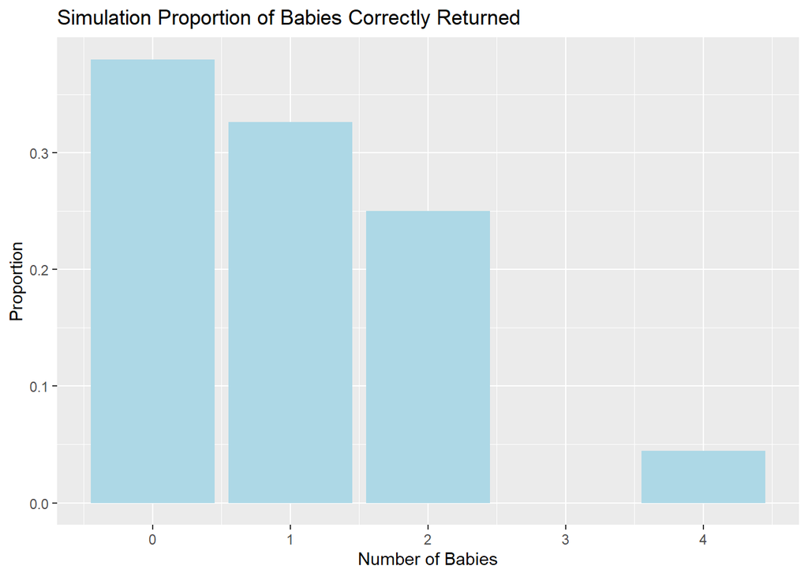

```r
# Q3 code, https://stackoverflow.com/questions/19389888/ggplot-barplot-does-not-accept-y-value

prop_data |>
  ggplot(aes(x = num)) +
  geom_bar(aes(y = prop), stat = "identity", fill = "lightblue") +
  labs(title = "Simulation Proportion of Babies Correctly Returned", x = "Number of Babies", y = "Proportion")
```

## Simulating Coverage

Many students struggle with the definition of a confidence interval when first learning the concept. The interpretation that a lot of textbooks include is somthing like “if we were to repeat the study many many times, 95% of the confidence intervals would contain the true population parameter.”

We are going to implement a simulation that illustrates this statistical concept using confidence intervals for the slope parameter in a linear regression model.

Let’s break it down into a couple of steps.

As a reminder, the typical population model that we assume for a linear regression is:

$$Y = \beta_0 + \beta_1 X + \varepsilon$$
Where $\beta_0$ and $\beta_1$ are the population intercept and slope parameters and and $\varepsilon \sim N(0, \sigma^2)$ is random noise that is normally distributed with mean 0 and variance $\sigma^2$.

We will design a simulation that uses this “data generating model.”

**4. Fill in the code below to generate a synthetic dataset with 100 observations. We will assume that the explanatory variable $X$ is uniformly distributed from 0 to 1 and that $\sigma^2$ = 1. The synthetic data should be a dataframe with 100 rows and two columns: `x` and `y`.**

```r
# define slope and intercept parameters, https://chatgpt.com/share/683897d2-6b64-8009-a060-621336f8504c
intercept = 2
slope = 1

# generate x vector
x = runif(100, min = 0, max = 1)


# generate noise `ep` vector
ep = rnorm(100, mean = 0, sd = 1)


# generate outcome from population model
y = intercept + x * slope + ep


# create an "observed data" dataframe with only the x and y vectors
observed_data = data.frame(x = x, y = y)
```

**5. Fit a simple linear regression model of the outcome `y` on `x`. Use `tidy()` from the `broom` package to extract a dataframe from the `lm()` output that includes the slope estimate and a 95% confidence interval for the slope estimate.**

```r
# Q5 code, https://broom.tidymodels.org/reference/tidy.lm.html

lm_data <- lm(y ~ x, data = observed_data)
lm_data_tidy <- broom::tidy(lm_data, conf.int = TRUE, conf.level = 0.95)
lm_data_tidy |> kable()
```

| term | estimate | std.error | statistic | p.value | conf.low | conf.high |
| --- | --- | --- | --- | --- | --- | --- |
| (Intercept) | 2.068986 | 0.2063897 | 10.024661 | 0.0000000 | 1.6594127 | 2.47856 |
| x | 1.042177 | 0.3650821 | 2.854637 | 0.0052587 | 0.3176835 | 1.76667 |

**6. Check whether the true population slope is inside of the estimated 95% confidence interval for that simulated dataset. Specifically, *add* a variable called `cover` to the dataframe of estimates you created in the last question (Q5) that is `1` if the population slope is in the interval and `0` if not.**

**Tip**

As a reminder, we set `slope = 1` in the data generation (Q4) so the true population slope is $\beta_1 = 1$.

```r
# Q6 code, https://chatgpt.com/share/683897d2-6b64-8009-a060-621336f8504c
lm_data_tidy <- lm_data_tidy |>
  filter(term == "x") |>
  mutate(cover = ifelse(conf.low <= 1 & conf.high >= 1, 1, 0))
```

**7. Now put this all together into a function called `mycifun`! Run the check provided to ensure that it works correctly**

- The function should have three required arguments: `beta0`, `beta1`, and `n` (the number of observations in the simulated data).
- The function should complete the steps in Q4-6 given these arguments:
  1. generate one synthetic dataset based on the data generating model as above
  2. fit a linear regression model
  3. check that the **population slope** is contained in the estimated 95% confidence interval for the sample slope
- The output of the function should be a dataframe/tibble with one row and four columns: the slope estimate, lower bound of the CI, upper bound of the CI, and whether the population slope is within the CI.

```r
# Q7 code
mycifun <- function(beta0, beta1, n){
  intercept <- beta0
  slope <- beta1
  ep <- rnorm(n, mean = 0, sd = 1)
  x <- runif(n, min = 0, max = 1)
  y <- intercept + (x * slope) + ep
  observed_data <- data.frame(x = x, y = y)
  lm_data <- lm(y ~ x, data = observed_data)
  lm_data_tidy <- broom::tidy(lm_data, conf.int = TRUE, conf.level = 0.95)
  lm_data_tidy <- lm_data_tidy |>
    filter(term == "x") |>
    mutate(cover = ifelse(conf.low <= slope & conf.high >= slope, 1, 0)) |>
    select(estimate, conf.low, conf.high, cover)
  return(lm_data_tidy)
}
```

```r
mycifun(beta0 = 1, beta1 = 2, n = 1000) |> kable()
```

| estimate | conf.low | conf.high | cover |
| --- | --- | --- | --- |
| 1.822081 | 1.60117 | 2.042992 | 1 |

**8a. Now run this simulation 1,000 times using `map_dfr()` and the function you wrote (`mycifun()`). Generate data with $\beta_0 = 3$, $\beta_1 = .5$ and $n = 100$. Make sure to add a line of code to make your simulation reproducible every time you run it.**

```r
set.seed(1234)

ci_dat <- map_dfr(.x = 1:1000,
                  .f = ~ mycifun(3, 0.5, 100)
                    )
```

**8b. What does one row in the resulting `ci_dat` represent?**

One row of ci_dat represents a simulation of simple linear regression of an estimated slope and shows the range of a 95% confidence interval and if the confidence interval covers the true slope of the synthetic data.

**8c. What is your simulated coverage rate? In otherwords, for what proportion of the iterations was the population slope within the estimated 95% confidence interval? Write your answer as a sentence in Markdown using inline code!**

The simulated coverage rate is 0.957.

```r
#https://chatgpt.com/share/683897d2-6b64-8009-a060-621336f8504c

mean(ci_dat$cover)
```

```
[1] 0.957
```

```r
# ci_dat |>
#   group_by(cover) |>
#   count() |>
#   ungroup() |>
#   mutate(prop = n / sum(n))
```

**9. Create a visualization to illustrate the coverage rate.**

You can create any visualization that effectively illustrates the concept. I included a plot in the lab assignment online with my idea of an effective plot to illustrate the concept of coverage. Actually, a professor showed me a plot like this in undergrad and I have always remembered it!

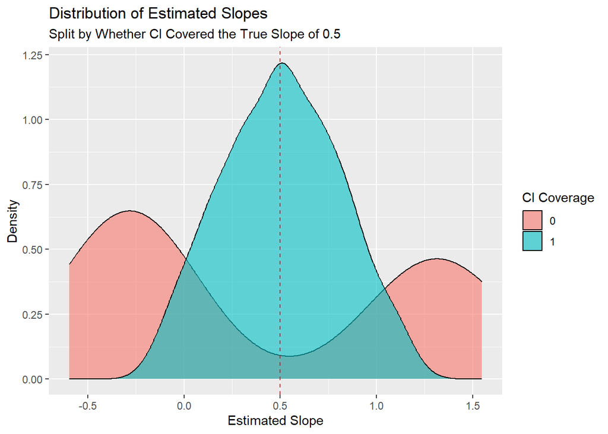

```r
# Q9 code, https://chatgpt.com/share/683897d2-6b64-8009-a060-621336f8504c

ci_dat |>
  ggplot(aes(x = estimate, fill = factor(cover))) +
  geom_density(alpha = 0.6) +
  geom_vline(xintercept = 0.5, color = "red", linetype = "dashed") +  # true slope
  labs(
    title = "Distribution of Estimated Slopes",
    subtitle = "Split by Whether CI Covered the True Slope of 0.5",
    x = "Estimated Slope",
    y = "Density",
    fill = "CI Coverage"
  )
```